# Regresja liniowa - projekt

Piotr Mikler, 409145

Sun Dec 05 18:04:00 2021

# 1 Wstęp

Projekt dotyczy regresji wielorakiej w zastosowaniu do predykcji własności mechanicznych betonu. Zaprezentowany jest wybór modelu regresji wielorakiej w oparciu o metody ilościowe i graficzną analizę reziduów modeli. Prezentuję naiwny model liniowy wykorzystujący wszystkie zmienne oraz bardziej zaawansowaną wersję w której używam liniowej regresji wielorakiej do modelowania nieliniowych przekształceń zmiennych. Prezentuję uzyskane polepszenie jakości modelu, oraz testuję jego stabilność przy użyciu walidacji krzyżowej danych treningowych, oraz przy użyciu zarezerwowanego zbioru testowego.

# 2 Przygotowanie danych

## 2.1 Opis danych

Będziemy pracować ze zbiorem danych dotyczącym komponentów betonu. Dane pochodzą z [UCI Machine Learning Repository](https://archive.ics.uci.edu/ml/datasets/concrete+compressive+strength) i zawierają $1030$ obserwacji $9$ zmiennych ciągłych.

Zmienne zawierają następujące informacje (opisy pozostawione w języku angielskim w celu zachowania wierności opisu):

| Kolumna | Jednostka | Opis |
| --- | --- | --- |
| Cement | $kg/m^3$ | Amount of cement in the mixture |
| Slag | $kg/m^3$ | Amount of blast furnace slag in the mixture |
| Ash | $kg/m^3$ | Amount of fly ash in the mixture |
| Water | $kg/m^3$ | Amount of water in the mixture |
| Superplasticizer | $kg/m^3$ | Amount of superplasticizer in the mixture |
| CoarseAgg | $kg/m^3$ | Amount of coarse aggregate in the mixture |
| FineAgg | $kg/m^3$ | Amount of fine aggregate in the mixture |
| Age | $Dni$ | Resting days before the compressive strength measurement |
| Strength | $MPa$ | Compressive strength of the final product |

```r
sDfPath <- paste0(getwd(), '/data/Concrete_Data.csv')
df <- read_csv(sDfPath)
sOrgColnames <- colnames(df)
colnames(df) <- c('Cement', 'Slag', 'Ash',
                  'Water', 'Superplasticizer',
                  'CoarseAgg', 'FineAgg', 'Age', 'Strength')

# 80/20 Train-test split
set.seed(115)
test_frac = 0.2
test_ind <- sample(seq_len(nrow(df)), size = floor(nrow(df)*test_frac))

test_set <- df[test_ind, ]
df <- df[-test_ind, ]

df %>% glimpse()
```

```
## Rows: 824
## Columns: 9
## $ Cement           <dbl> 332.5, 198.6, 266.0, 380.0, 266.0, 475.0, 198.6, 4...
## $ Slag             <dbl> 142.5, 132.4, 114.0, 95.0, 114.0, 0.0, 132.4, 47.5...
## $ Ash              <dbl> 0, 0, 0, 0, 0, 0, 0, 0, 0, 0, 0, 0, 0, 0, 0, 0, 0,...
## $ Water            <dbl> 228, 192, 228, 228, 228, 228, 192, 228, 228, 192, ...
## $ Superplasticizer <dbl> 0, 0, 0, 0, 0, 0, 0, 0, 0, 0, 0, 0, 0, 0, 0, 0, 0,...
## $ CoarseAgg        <dbl> 932.0, 978.4, 932.0, 932.0, 932.0, 932.0, 978.4, 9...
## $ FineAgg          <dbl> 594.0, 825.5, 670.0, 594.0, 670.0, 594.0, 825.5, 5...
## $ Age              <dbl> 270, 360, 90, 28, 28, 28, 28, 270, 90, 90, 365, 18...
## $ Strength         <dbl> 40.27, 44.30, 47.03, 36.45, 45.85, 39.29, 28.02, 4...
```

## 2.2 Cel projektu

Modelowaną zmienną będzie `Strength`, czyli wytrzymałość betonu na ściskanie. Jest to istotna wlasność w dziedzinie wytrzymałości materiału opisująca ile jednostek ciśnienia (mierzonych zazwyczaj w $MPa$) może on przyjąć zanim ulegnie stałej deformacji, pęknięciu lub skruszeniu.

Będziemy modelować `Strength` na podstawie zmiennych niezależnych opisujących ilość składników w mieszance tworzącej beton, oraz czas wiązania betonu. Postaramy się odpowiedzieć na następujące pytania:  
* czy model liniowy jest dobrym wyborem dla tej zależności  
* czy/które założenia modelu regresji wielorakiej są spełnione  
* jakie czynniki najbardziej wpływają na wytrzymałość betonu

## 2.3 Przegląd danych

```r
df %>% summary()
```

```
##      Cement           Slag             Ash             Water
##  Min.   :102.0   Min.   :  0.00   Min.   :  0.00   Min.   :121.8
##  1st Qu.:194.4   1st Qu.:  0.00   1st Qu.:  0.00   1st Qu.:164.9
##  Median :275.0   Median : 20.00   Median :  0.00   Median :185.0
##  Mean   :280.8   Mean   : 73.77   Mean   : 53.79   Mean   :181.4
##  3rd Qu.:350.0   3rd Qu.:145.00   3rd Qu.:118.30   3rd Qu.:192.0
##  Max.   :540.0   Max.   :359.40   Max.   :200.00   Max.   :247.0
##  Superplasticizer   CoarseAgg         FineAgg           Age
##  Min.   : 0.000   Min.   : 801.0   Min.   :594.0   Min.   :  1.00
##  1st Qu.: 0.000   1st Qu.: 932.0   1st Qu.:734.3   1st Qu.:  7.00
##  Median : 6.400   Median : 968.0   Median :779.9   Median : 28.00
##  Mean   : 6.182   Mean   : 972.1   Mean   :775.9   Mean   : 43.67
##  3rd Qu.:10.200   3rd Qu.:1028.7   3rd Qu.:825.5   3rd Qu.: 56.00
##  Max.   :32.200   Max.   :1145.0   Max.   :992.6   Max.   :365.00
##     Strength
##  Min.   : 2.33
##  1st Qu.:23.52
##  Median :34.27
##  Mean   :35.69
##  3rd Qu.:45.91
##  Max.   :81.75
```

Szczęśliwie w naszych danych nie ma obserwacji brakujących. Mamy do czynienia ze zmiennymi ciągłymi, mimo że granularność pomiaru niektórych z nich dyskretyzuje ich dziedzinę. Mimo tego będę rozpatrywał je jako zmienne ciągłe. Mamy dużo unikalnych wartości, mają one naturalny porządek oraz ten porządek wydaje się mieć sens w kontekscie modelu, jako że reprezentuje ciągłą wartość fizyczną.

Rozpoczniemy analizę od rozeznania się w rozkładach zmiennych. Wyrysujmy boxploty, histogramy i empiryczne gęstości aby zorientować się w rozkładach zmiennych.

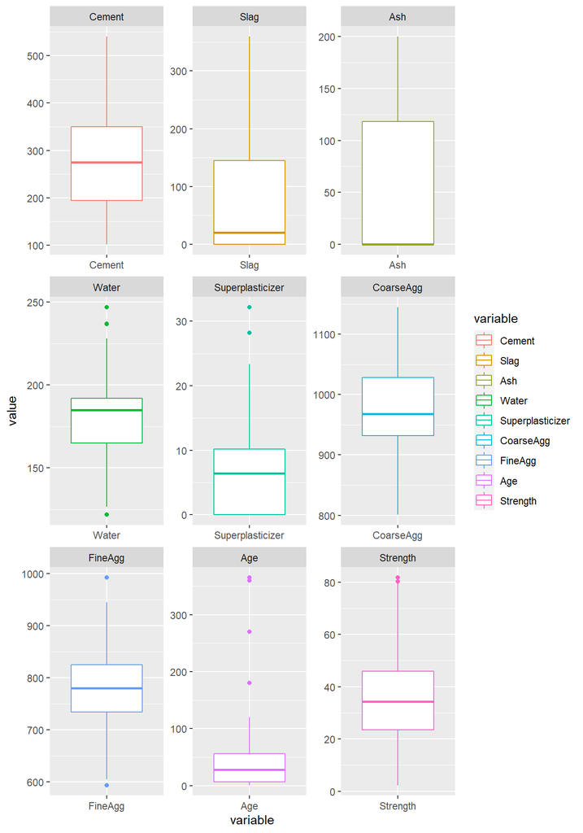

```r
discrete_variables <- NULL
continuous_variables <- setdiff(colnames(df), discrete_variables)

df_long <- df %>%
  select(all_of(continuous_variables)) %>%
  as.data.table(keep.rownames = 'Vars') %>%
  melt(id.vars = "Vars") %>%
  mutate(Vars = as.numeric(Vars))

df_long %>%
  ggplot(aes(x=variable, y = value, color = variable)) +
  geom_boxplot() + facet_wrap(~variable, scales='free', ncol = 3)
```

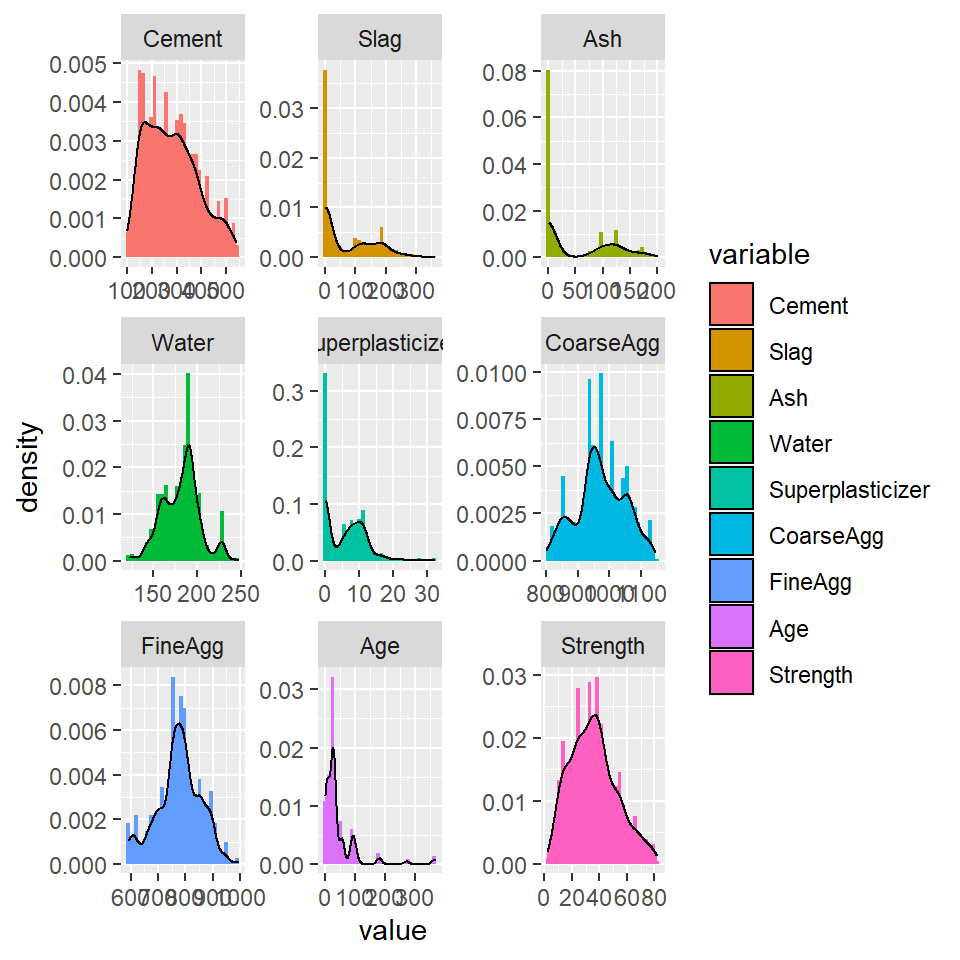

```r
df_long %>%
  ggplot(aes(x=value, fill = variable, y = ..density..)) +
  geom_histogram(bins=30) + facet_wrap(~variable, scales='free', ncol = 3) + geom_density()
```

Dokładniejszą anaizę obserwacji odstających przeprowadzimy po dopasowaniu finalnego modelu. Obserwując powyższe wykresy widzimy jednak już teraz, że w danych mamy obserwacje odstające ze względu na definicję wąsów z wykresu pudełkowego. Nie są to jednak obserwacje błędne pod względem możliwych wartości jakie w rzeczywistości mogą przyjmować te zmienne. Wyjątkiem jest `Age` - beton osiąga maksimum wytrzymałości już po około miesiącu, więc wykonywanie pomiarów po około $100/200/300$ dni wydaje się mieć mało sensu. Przy drugim podejściu do modelu spróbujemy przetransformować je nieliniową funkcją a jesli to nie pomoże - usuniemy je.

Zanim przejdziemy do modelowania rzućmy okiem na zależności pomiedzy danymi. Będę używał korelacji rangowej ($\tau$ Kendalla) z dwóch powodów. Po pierwsze $\rho$ Pearsona jest niemiarodajna przy takich rozkładach danych jak widoczne na histogramach. Po drugie nawet płytki research w tematykę wytrzymałości materiałów pozwala podejrzewać silną nieliniowość w zależnościach.

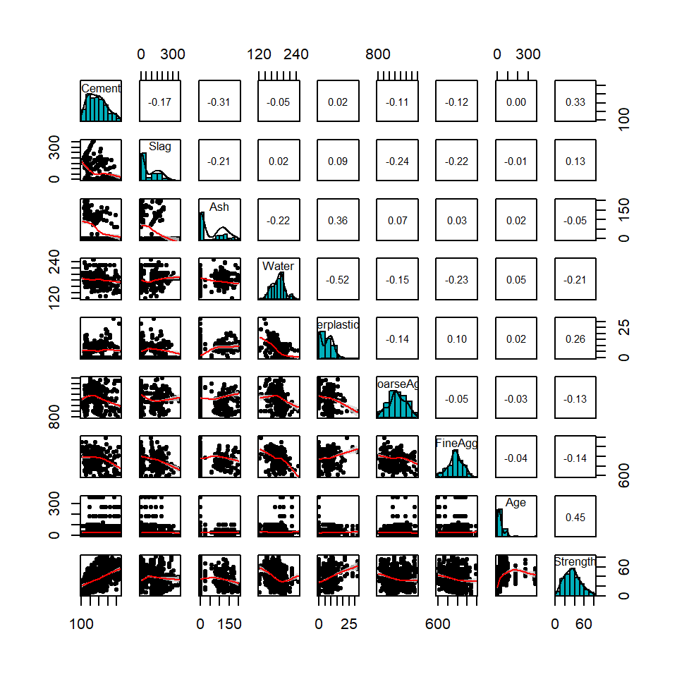

```r
pairs.panels(df,
             method = "kendall",
             hist.col = "#00AFBB",
             density = TRUE,
             ellipses = FALSE,
             ci=TRUE
             )
```

Wstępnie wygląda na to, że `Strength` będzie silnie odpowiadało na `Age`, `Cement` oraz `Superplasticizer`. Wydaje się to być zgodne z intuicją. Widać również opisany wcześniej efekt między `Age`, a `Strength`- mocna odpowiedź zmiennej zależnej w pierwszych dniach wiązania betonu i nagłe wygaszenie relacji po osiągnięciu około miesiąca.

# 3 Wstępny wybór zmiennych niezależnych

Wszystkie zmienne wydają się być sensowne w modelowaniu naszej zmiennej zależnej. Wstępny model dopasujemy więc na wszystkich dostępnych zmiennych, nie przeprowadzając żadnej korekty danych. Zobaczymy następnie czy można zredukować lub poprawić model poprzez odpowiednie zabiegi na danych wejściowych oraz redukcję zmiennych.

## 3.1 Dopasowanie modelu i diagnostyka

```r
model_full <- lm(Strength~., data=df)
summary(model_full)
```

```
##
## Call:
## lm(formula = Strength ~ ., data = df)
##
## Residuals:
##     Min      1Q  Median      3Q     Max
## -29.986  -6.696   0.654   6.468  34.497
##
## Coefficients:
##                   Estimate Std. Error t value Pr(>|t|)
## (Intercept)      -2.429138  29.085129  -0.084 0.933460
## Cement            0.116015   0.009201  12.608  < 2e-16 ***
## Slag              0.103202   0.011071   9.322  < 2e-16 ***
## Ash               0.082169   0.013792   5.958 3.81e-09 ***
## Water            -0.169333   0.043752  -3.870 0.000117 ***
## Superplasticizer  0.306642   0.102877   2.981 0.002962 **
## CoarseAgg         0.009836   0.010333   0.952 0.341428
## FineAgg           0.009856   0.011791   0.836 0.403472
## Age               0.117328   0.006228  18.839  < 2e-16 ***
## ---
## Signif. codes:  0 '***' 0.001 '**' 0.01 '*' 0.05 '.' 0.1 ' ' 1
##
## Residual standard error: 10.27 on 815 degrees of freedom
## Multiple R-squared:  0.6351, Adjusted R-squared:  0.6315
## F-statistic: 177.3 on 8 and 815 DF,  p-value: < 2.2e-16
```

Opis modelu sugeruje, że dobrane zmienne są w nim istotne, poza dwoma rodzajami kruszywa. `CoarseAgg` oraz `FineAgg` mają jednak bardzo podobne współczynniki regresji - może to sugerować, że dla modelu zupełnie nieistotne jest rozbicie na dwa rodzaje kruszywa. Warto spróbować dopasować model bez podziału na grubo- i drobnoziarniste kruszywo. Nie wgłebiajmy się jednak w takie analizy zanim nie upewnimy się, że założenia modelu są choć w przybliżeniu spełnione, a wyniki miarodajne.

### 3.1.1 Rozkład reszt

Sprawdzimy najpierw rozkład reziduów modelu.

```r
shapiro.test(model_full$residuals)
```

```
##
##  Shapiro-Wilk normality test
##
## data:  model_full$residuals
## W = 0.99573, p-value = 0.02259
```

```r
ncvTest(model_full)
```

```
## Non-constant Variance Score Test
## Variance formula: ~ fitted.values
## Chisquare = 92.93997, Df = 1, p = < 2.22e-16
```

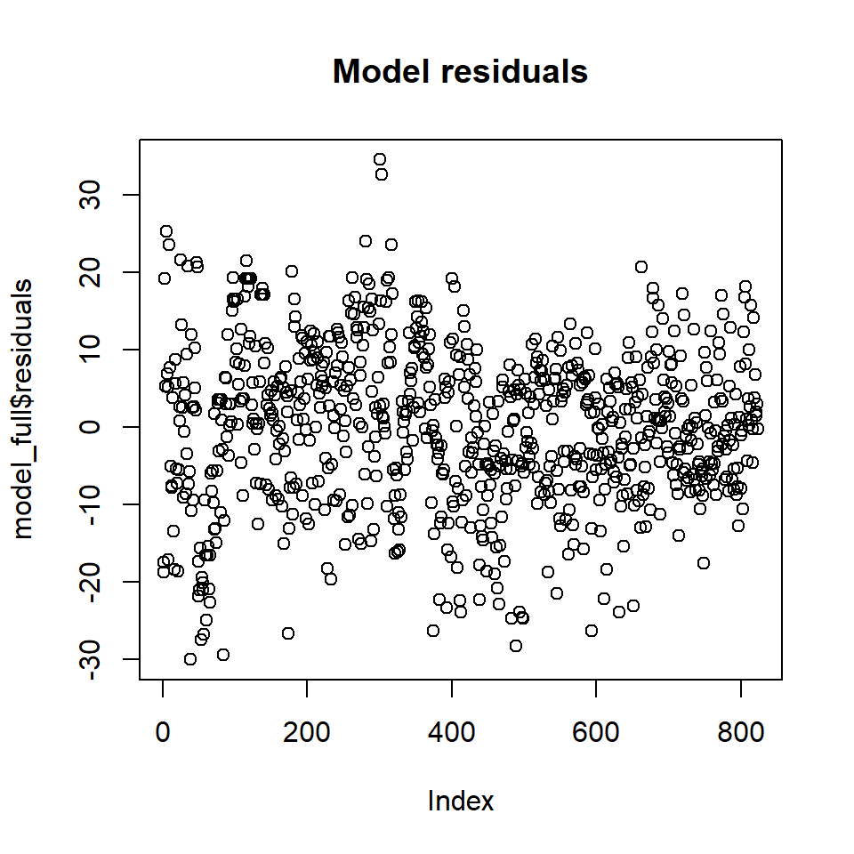

```r
fit <- fitdistr(model_full$residuals, "normal")
params <- fit$estimate

# Rozkłady reziduów
plot(model_full$residuals, main = "Model residuals")
```

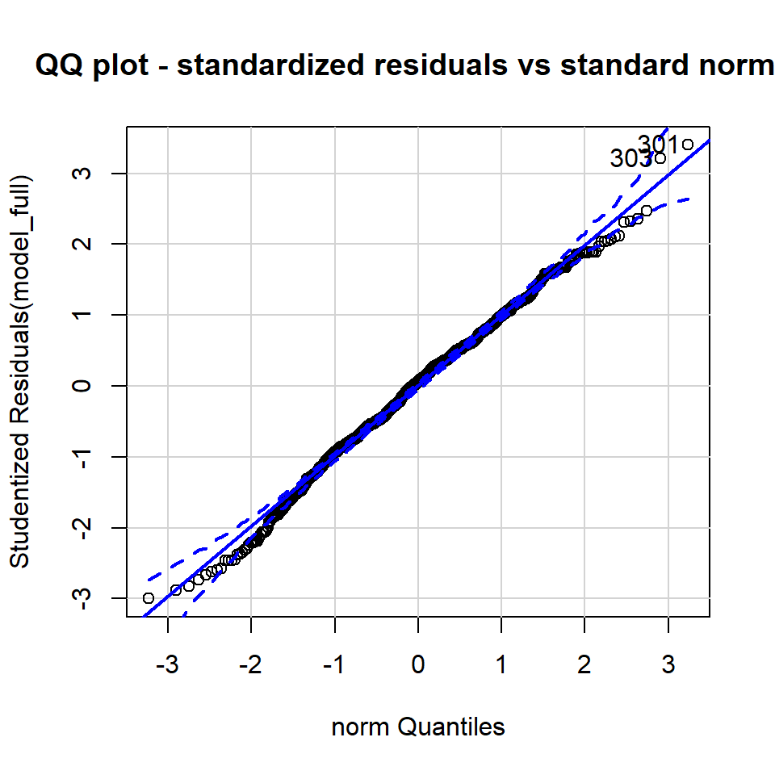

```
## [1] 301 303
```

```r
qqPlot(model_full, distribution='norm', main = "QQ plot - standardized residuals vs standard normal")
```

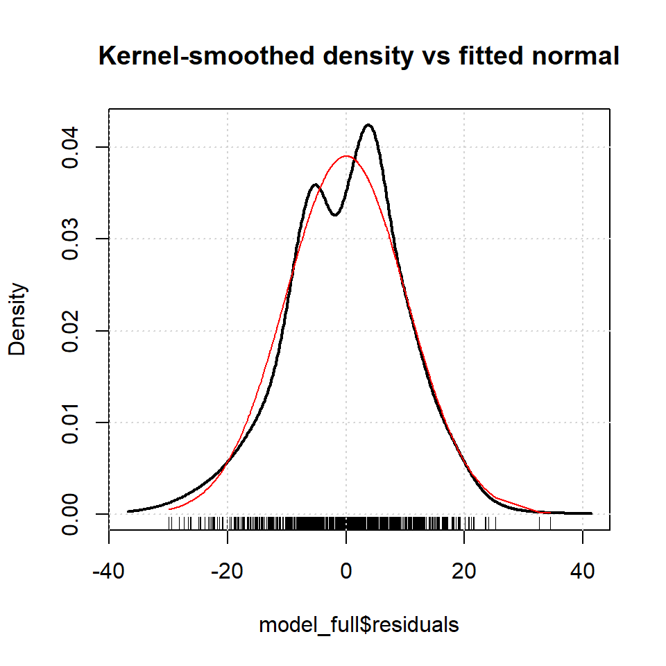

```r
densityPlot(model_full$residuals, main = "Kernel-smoothed density vs fitted normal")
lines(sort(model_full$residuals), dnorm(sort(model_full$residuals), params[1], params[2]), col='red')
```

Test Shapiro-Wilka odrzuca hipotezę normalności - najprawdopodobniej ze względu na dwie obserwacje w prawym ogonie wyróżnione na wykresie kwantylowym, oraz bimodalność widoczną na kernel density plot. Tak samo odrzucana jest hipoteza ich homoskedastyczności. Dodatkowo, poniżej widzimy że rezidua są zależne zarówno od predyktorów, jak od interakcji między nimi.

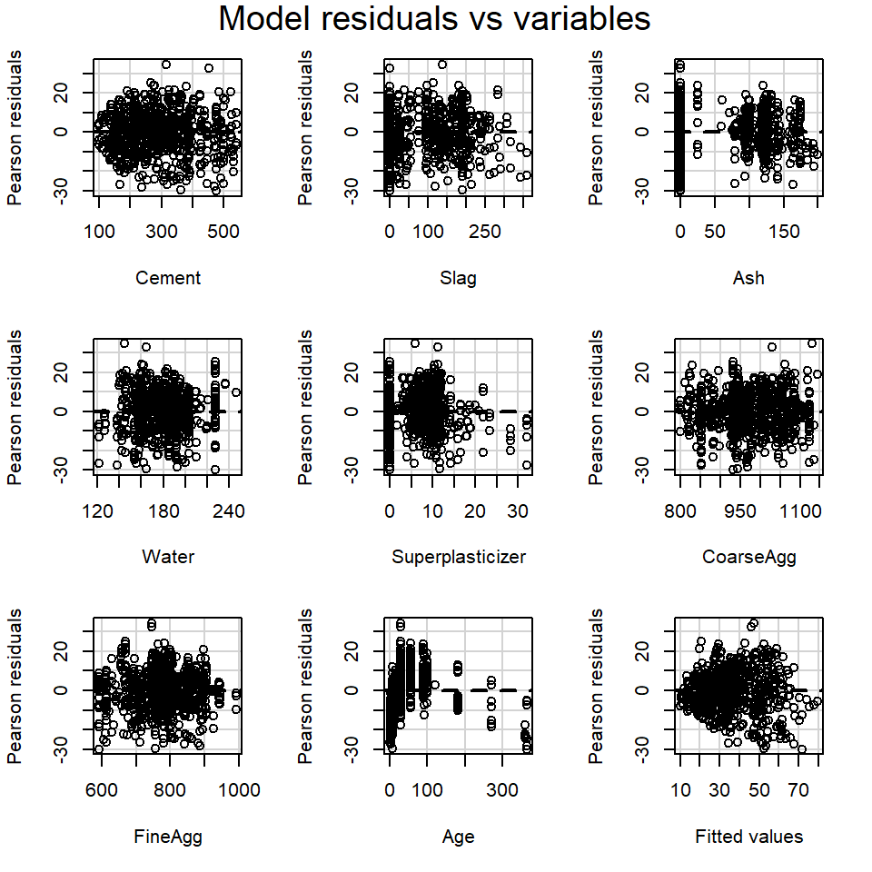

```r
# Zależność od zmiennych
residualPlots(model_full, tests=FALSE, main = "Model residuals vs variables", quadratic=FALSE, linear=TRUE)
```

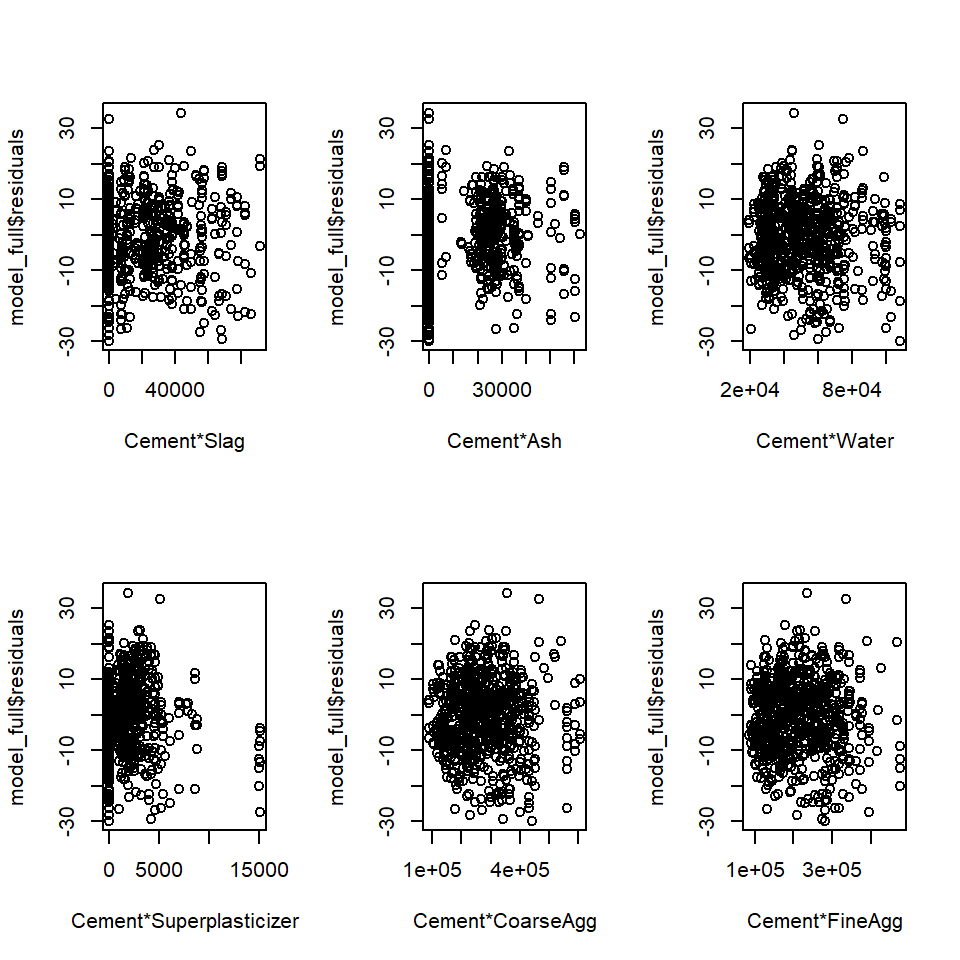

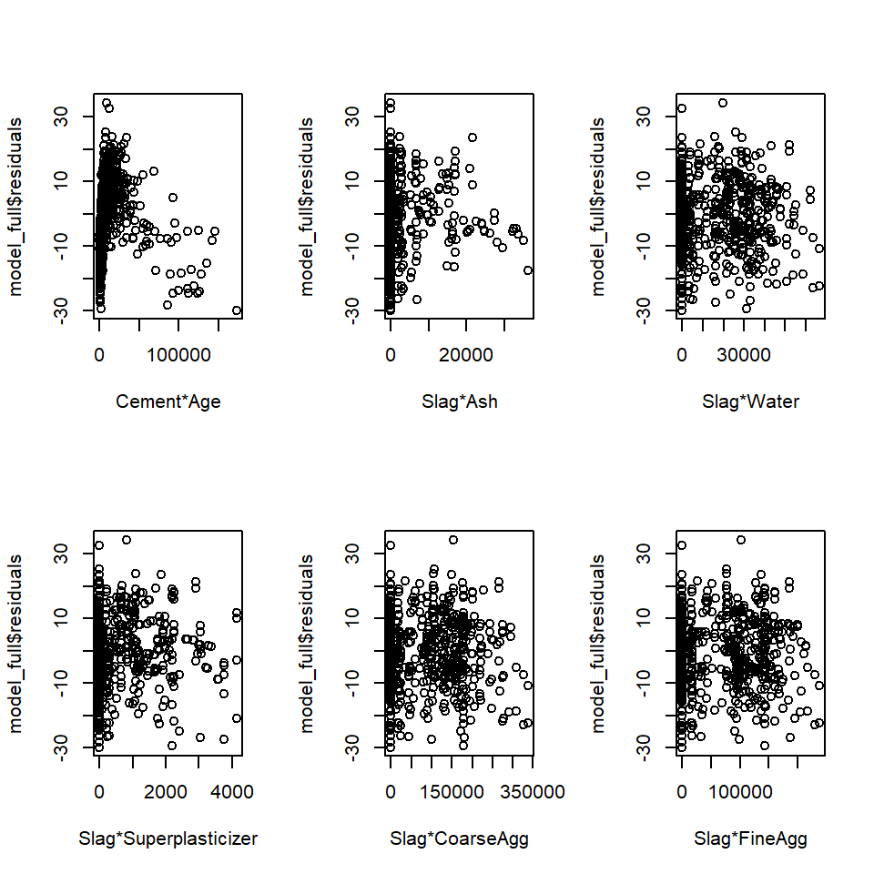

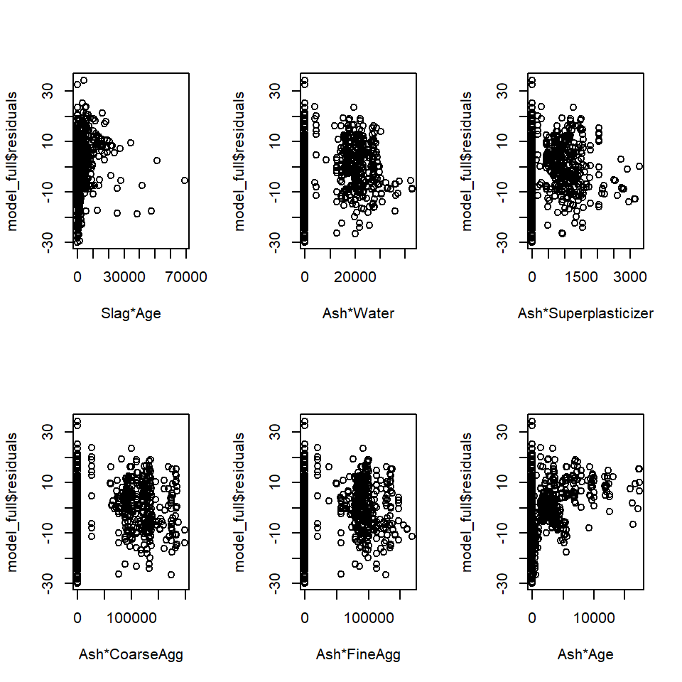

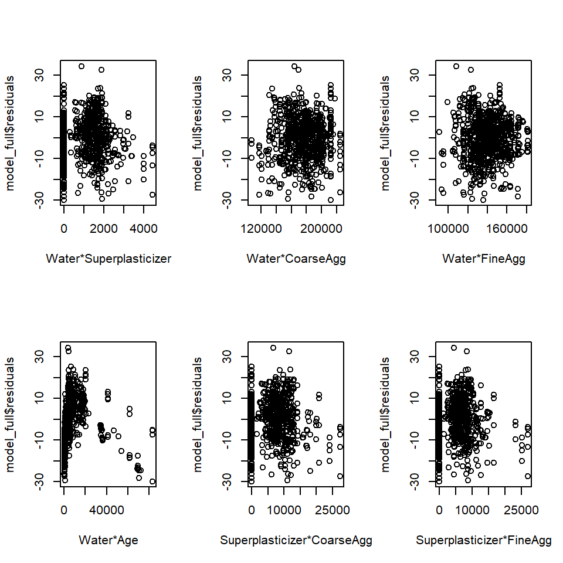

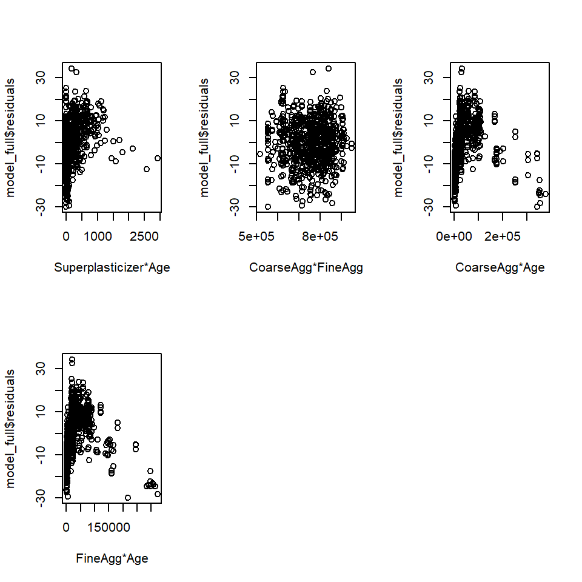

```r
# Zależności reziduów od interakcji
a <- attr(terms(lm(Strength ~ (.)^2, data = df)), 'term.labels')

op <- par(mfrow=c(2, 3))
junk_output <- with(df,
                    lapply(gsub(':', '*', a[grep(':', a)]), function(x)
                      plot(eval(parse(text=x)), model_full$residuals, xlab=x)))
```

Ten model nie jest dobry. Zarówno na wykresach zależności reziduów od zmiennych niezależnych, jak i ich interakcji widzimy, że przede wszystkim powinniśmy popracować nad zmienną `Age`. Dodatkowo obserwując rezidua w funkcji `Slag` i `Superplasticizer` wygląda jak gdyby możliwa była poprawa liniowości modelu poprzez transformację tych zmiennych.

## 3.2 Poprawa modelu

Poniżej opisane akcje wykonywane były krokowo, za każdym razem kontrolując *AIC*, *adjusted R<sup>2</sup>* i *MSE* otrzymanego modelu. Dla czytelności raportu nie prezentuję każdego kroku po kolei, a jedynie finalny model wybrany przy pomocy tych kryteriów.

### 3.2.1 Transformacje zmiennych

Literatura naukowa badająca właściwości betonu jednoznacznie mówi, że mieszanka tworząca beton zwiększa swoją wytrzymałość przez średnio $28$ dni zanim osiągnie swoje maksimum. Z tego powodu, sensowna wydaje się być transformacja $\min(\alpha, Age)$, ponieważ wartości `Age` powyżej pewnej wartości granicznej $\alpha$ nie powinny zwiększać wytrzymałości betonu. Przyjmiemy $\alpha$ troszkę powyżej $28$, ponieważ jest ona określana jako wartość średnia dla betonu - więc możliwe jest że dla niektórych mieszanek wartości $30/35$ będą wciąż niosły wartościową informację. Po kilku próbach przyjąłem $\alpha = 35$. Finalny model zawierać będzie kilka innych transformacji, jednak to ta była **kluczowa** dla usunięcia bimodalności reziduów. Próbowałem poprowadzić tę ideę dalej i dodać oprócz/zamiast przetransformowanej `Age` również interakcje między nią a `Cement` i `Superplasticizer` - nie prowadziło to jednak do znaczącego poleszenia predykcji modelu w stosunku do modelu ze zwykła transformacją `Age`. Otrzymywaliśmy model o wyższym stopniu komplikacji, ale nie było istotnej różnicy w *MSE*). Z tego powodu zostałem przy $\min(35, Age)$.

Z wykresów zależności reziduów wciąż widać było ich nieliniowe zależności ze zmiennymi `Water`, `Cement` i `Ash`. Próbowałem więc użyć w regresji tych zmiennych w ich pierwszej i drugiej potędze. Oba te zabiegi poprawiają *AIC*, *adjusted R<sup>2</sup>* i *MSE* w znaczący sposób, więc wielomiany drugiego stopnia zostały ujęte w modelu. Ten sam zabieg przeprowadzony na `Ash` nie przyniósł podobnego efektu - z tego powodu ta zmienna nie została transformowana.

Predykcje tak otrzymanego modelu wykazywały systematyczny błąd względem rzeczywistych wartości zmiennej objaśnianej. Kształt wykresu rezidów sugerował transformację zmiennej objaśnianej poprzez funkcję logarytmiczną lub pierwiastkową - po przetestowaniu tych możliwości pierwiastek dał lepszy finalny rezultat pod względem *adjusted R<sup>2</sup>* i *MSE*.

### 3.2.2 Redukcja ilości zmiennych

W celu redukcji zmiennych przyjrzałem się bliżej opisowi modelu który powstał wyżej. Zauważyć można, że współczynniki przy `CoarseAgg` oraz `FineAgg` są podobne, oraz że w ogólności zależności między reziduami a każdą z tych zmiennych wyglądają podobnie. Pozwoliłem sobie więc spróbować dopasować model który nie rozróżnia kruszywa gruboziarnistego od drobnoziarnistego (używa ich sumy jako zmiennej). Przeprowadziłem test anova między tymi dwoma modelami - nie wykazał on istotnej statystycznej różnicy ($p_{val} = 0.4277$) - co pozwala uprościć model.

### 3.2.3 Współliniowość zmiennych

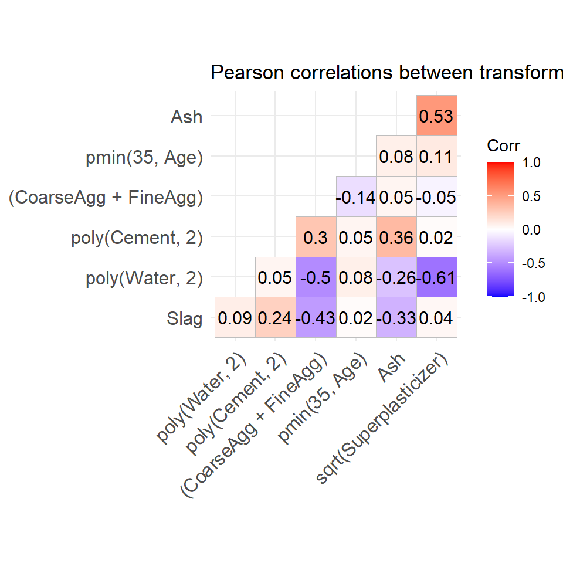

```r
df2 <- df %>%
  mutate('sqrt(Strength)' = sqrt(Strength),
         'sqrt(Superplasticizer)' = sqrt(Superplasticizer),
         'poly(Cement, 2)' = Cement*cement_coeffs[1] + Cement^2*cement_coeffs[2],
         'poly(Water, 2)' = Water*water_coeffs[1] + Water^2*water_coeffs[2],
         '(CoarseAgg + FineAgg)' = CoarseAgg + FineAgg,
         'pmin(35, Age)' = pmin(35, Age)) %>%
  select(-c('Superplasticizer', 'Age', 'Cement', 'Water', 'FineAgg', 'CoarseAgg'))

ggcorrplot::ggcorrplot(cor(select(df2, -c('sqrt(Strength)', 'Strength'))), type="lower", hc.order = TRUE, lab = TRUE, title = "Pearson correlations between transformed variables")
```

# 4 Wybór modelu i diagnostyka

Finalnie dopsujemy więc model regresji wielorakiej:
$$\sqrt{\text{Strength}} = \alpha + \beta_1 \text{Cement} + \beta_2 \text{Cement}^2 + \beta_3(\text{CoarseAgg + FineAgg}) + \beta_4 \text{Ash} + \\
\qquad \qquad \quad + \beta_5 \sqrt{Superplasticizer} + \beta_6 \text{Slag} + \beta_7 \text{Slag}^2 + \min(\text{Age}, 35) + \epsilon$$
Model jest skomplikowany lecz należało tego oczekiwać, ponieważ jak czytamy w prawie każdej publikacji naukowej z dziedziny wytrzymałości materiałów ‘compressive strength is a highly non-linear function of the mixture components’.

```r
challenger_model <- lm(formula = sqrt(Strength) ~
                         poly(Cement, 2) +
                         I(CoarseAgg + FineAgg) +
                         Ash +
                         poly(Slag, 2) +
                         sqrt(Superplasticizer)+
                         pmin(Age, 35),
                       data = df)

summary(challenger_model)
```

```
##
## Call:
## lm(formula = sqrt(Strength) ~ poly(Cement, 2) + I(CoarseAgg +
##     FineAgg) + Ash + poly(Slag, 2) + sqrt(Superplasticizer) +
##     pmin(Age, 35), data = df)
##
## Residuals:
##      Min       1Q   Median       3Q      Max
## -1.75914 -0.41428 -0.03905  0.37654  1.99917
##
## Coefficients:
##                          Estimate Std. Error t value Pr(>|t|)
## (Intercept)            -4.3278454  0.5832565  -7.420 2.94e-13 ***
## poly(Cement, 2)1       39.4348247  1.1138419  35.404  < 2e-16 ***
## poly(Cement, 2)2       -4.4844800  0.6037673  -7.427 2.79e-13 ***
## I(CoarseAgg + FineAgg)  0.0044259  0.0003253  13.604  < 2e-16 ***
## Ash                     0.0092618  0.0006828  13.565  < 2e-16 ***
## poly(Slag, 2)1         27.6584962  1.1908600  23.226  < 2e-16 ***
## poly(Slag, 2)2         -2.8531988  0.6162687  -4.630 4.26e-06 ***
## sqrt(Superplasticizer)  0.0646414  0.0205087   3.152  0.00168 **
## pmin(Age, 35)           0.0768592  0.0017721  43.372  < 2e-16 ***
## ---
## Signif. codes:  0 '***' 0.001 '**' 0.01 '*' 0.05 '.' 0.1 ' ' 1
##
## Residual standard error: 0.5869 on 815 degrees of freedom
## Multiple R-squared:  0.8417, Adjusted R-squared:  0.8401
## F-statistic: 541.6 on 8 and 815 DF,  p-value: < 2.2e-16
```

## 4.1 Zależności reszt od zmiennych niezależnych

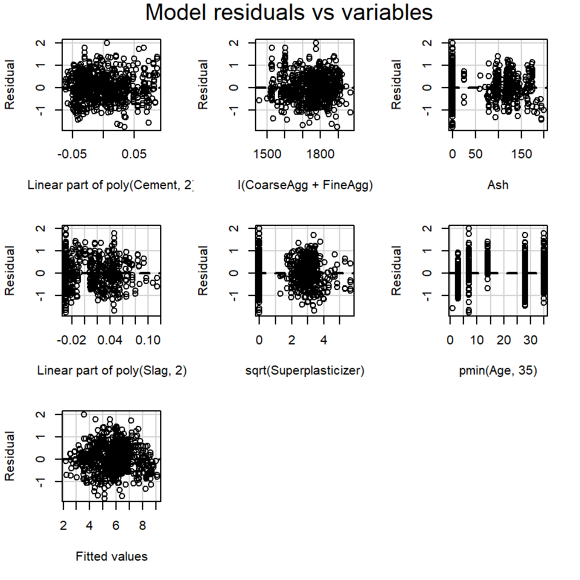

```r
residualPlots(challenger_model, tests=FALSE, main = "Model residuals vs variables", quadratic=FALSE, ylab='Residual')
```

Wykresy zależności reziduów od zmiennych niezależnych nie pokazują istotnych trendów czy zależności. Wygląda na to, że udało się w sensowny sposób przetransformować dane.

## 4.2 Rozkład reszt

```r
shapiro.test(challenger_model$residuals)
```

```
##
##  Shapiro-Wilk normality test
##
## data:  challenger_model$residuals
## W = 0.99786, p-value = 0.3798
```

```r
ncvTest(challenger_model)
```

```
## Non-constant Variance Score Test
## Variance formula: ~ fitted.values
## Chisquare = 0.169078, Df = 1, p = 0.68093
```

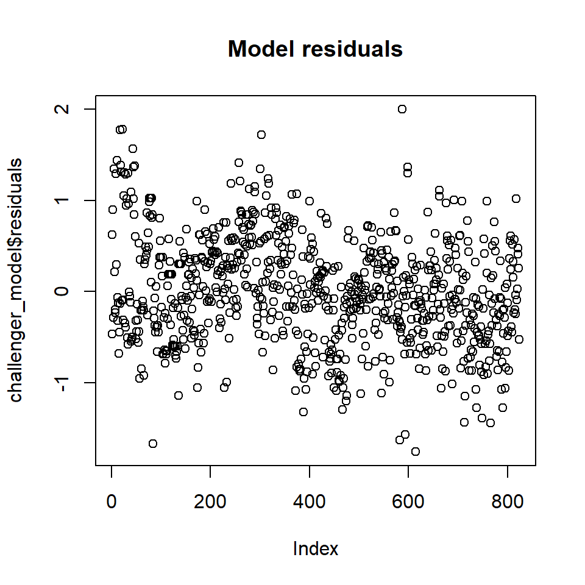

```r
fit <- fitdistr(challenger_model$residuals, "normal")
params <- fit$estimate
plot(challenger_model$residuals, main = "Model residuals")
```

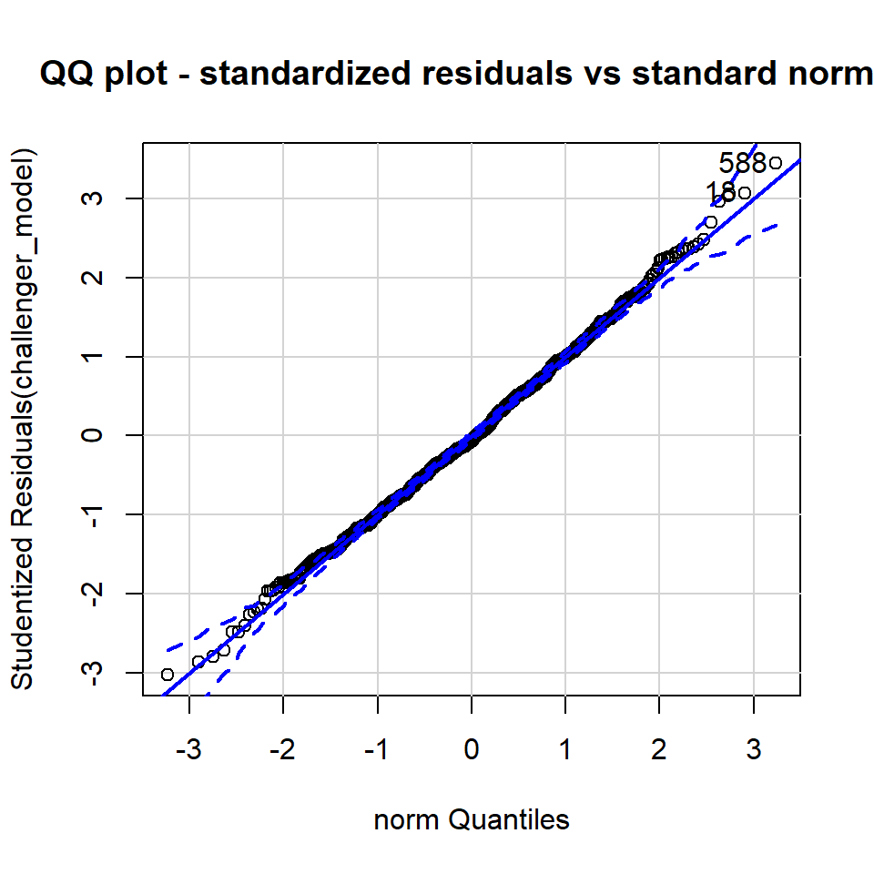

```
## [1]  18 588
```

```r
qqPlot(challenger_model, distribution='norm', main = "QQ plot - standardized residuals vs standard normal")
```

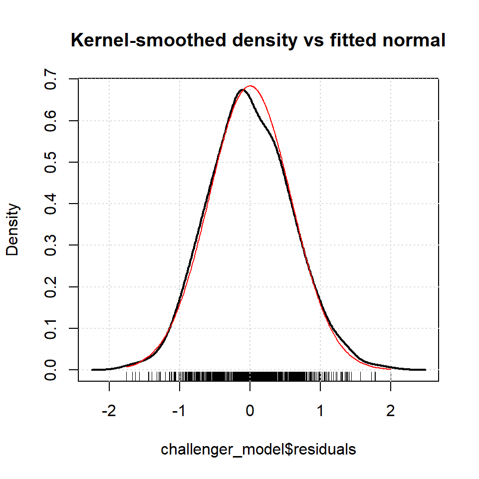

```r
kde<-densityPlot(challenger_model$residuals, main = "Kernel-smoothed density vs fitted normal", method='kernel')
lines(sort(challenger_model$residuals), dnorm(sort(challenger_model$residuals), params[1], params[2]), col='red')
```

Rozkład reszt badaliśmy pod względem normalności i homoskedastyczności. Rozkład reziduów nie powoduje odrzucenia hipotezy zerowej testu Shapiro-Wilka, oraz non-constant variance score. Wykres kwantyl-kwantyl wygląda bardzo dobrze - kwantyle reszt modelu układają się współliniowo z kwantylami rozkładu standardowego normalnego. Na ostatnim wykresie możemy obserwować gęstość empiryczną rozkładu rezidów, oraz gęstość dopasowanego rozkładu normalnego - widzimy że są bardzo blisko siebie.

## 4.3 Czynniki interakcji

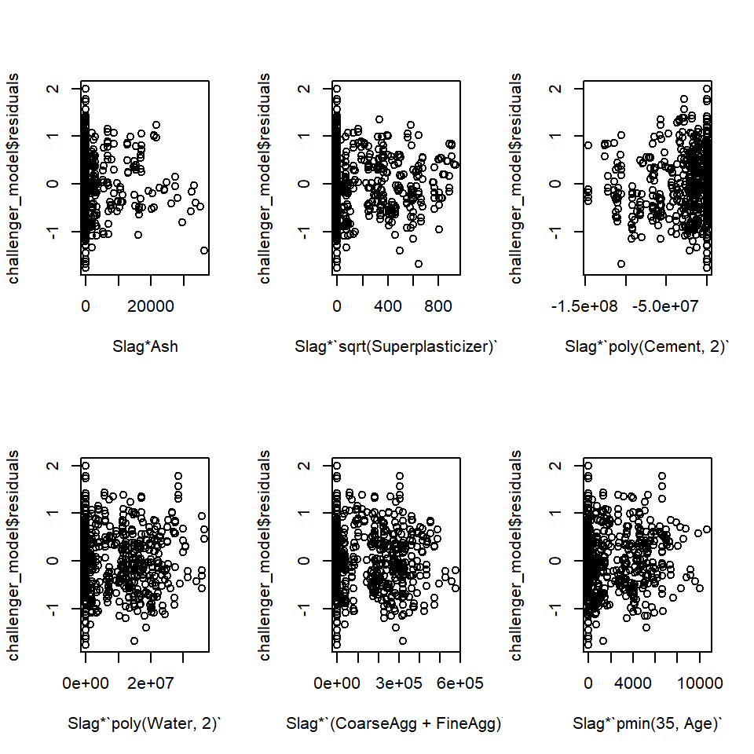

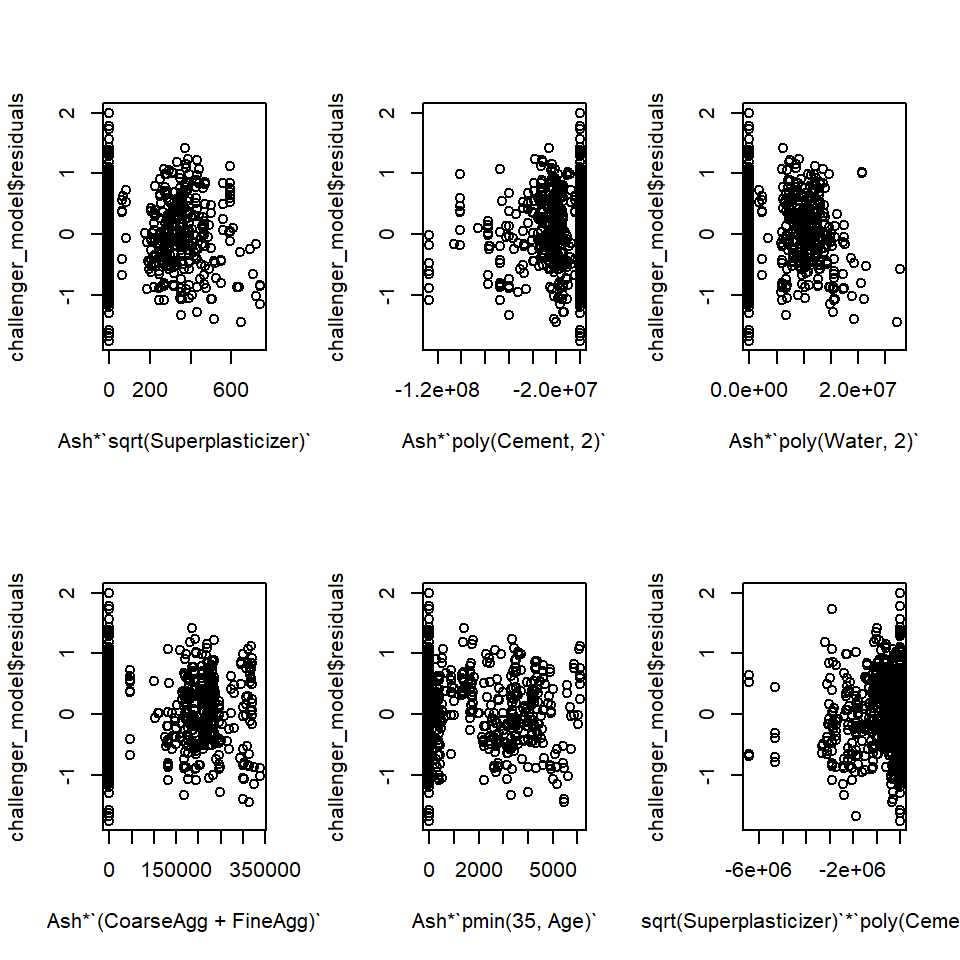

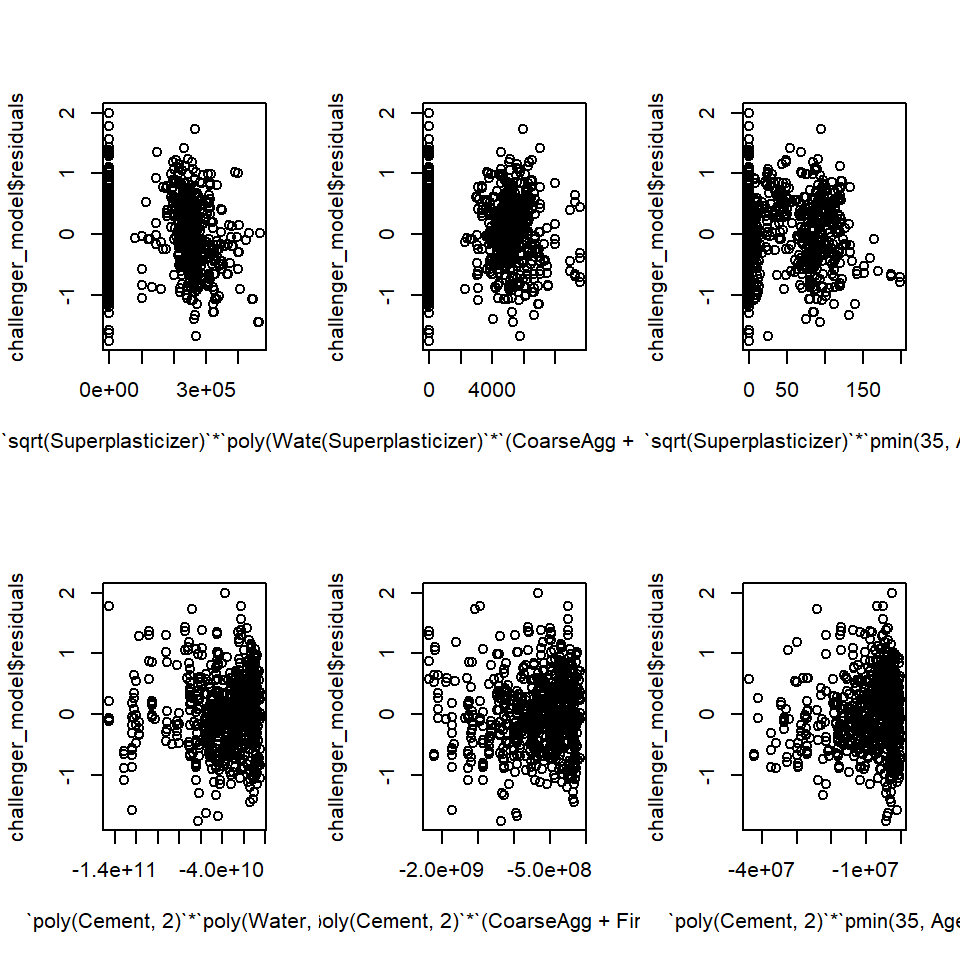

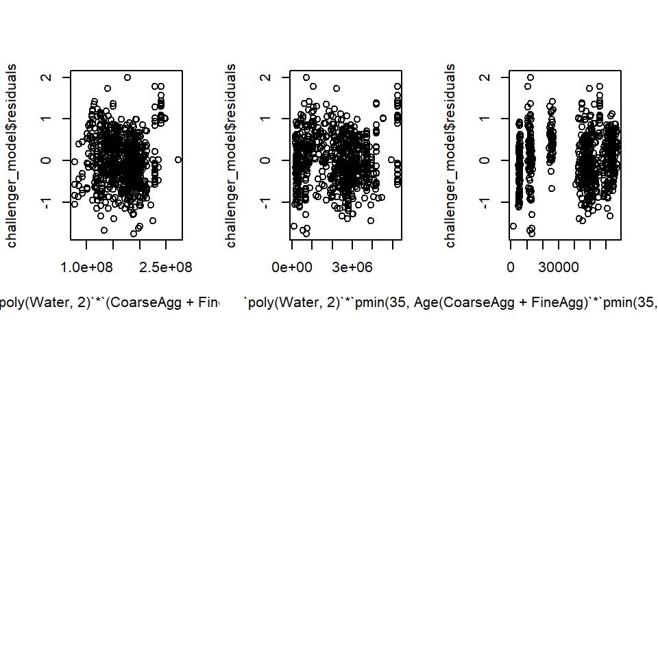

```r
a <- attr(terms(lm(`sqrt(Strength)`~ (.)^2, data = select(df2, -c('Strength')))), 'term.labels')


op <- par(mfrow=c(2, 3))
junk_output <- with(select(df2, -c('sqrt(Strength)')),
                    lapply(gsub(':', '*', a[grep(':', a)]), function(x)
                      plot(eval(parse(text=x)), challenger_model$residuals, xlab=x)))
```

Obserwując wykresy może się wydawać, że mamy w modelu zależności reziduów od interakcji między przetransformowanymi zmiennymi niezależnymi. Próbując jednak kolejno dodać interakcje do modelu ich współczynniki nie były wskazywane jako istotne - z tego powodu nie włączam interakcji do modelu.

## 4.4 Obserwacje odstające

Obserwacje nietypowe postaramy się zidentyfikować przede wszystkim na podstawie tabeli ‘influence measures’. Przedtem rzućmy jednak okiem na wykres standaryzowanych reziduów, wykres reszt od dźwigni oraz half-normal plot dystansów Cooke’a.

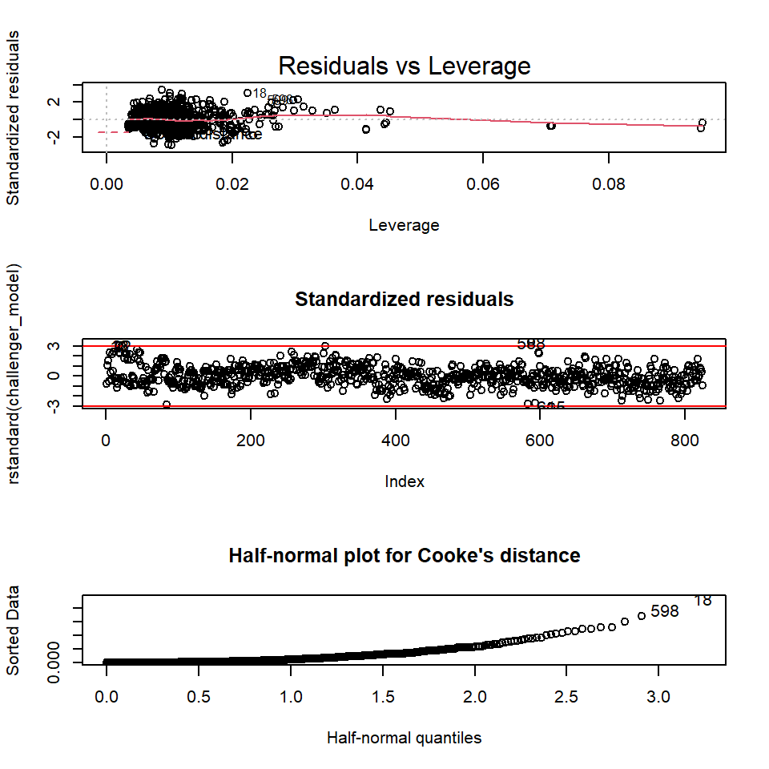

```r
par(mfrow=c(3, 1))
plot(challenger_model, which = c(5))
plot(rstandard(challenger_model), main = "Standardized residuals")
ind <- as.numeric(names(which(abs(rstandard(challenger_model))>3)))
abline(h=3, col='red')
abline(h=-3, col='red')
text(x = ind, y=rstandard(challenger_model)[ind], labels = as.character(ind))

halfnorm(cooks.distance(challenger_model), main = "Half-normal plot for Cooke's distance")
```

Wykresy pokazują że nie ma wiele istotnie odstających obserwacji. Pojawia się kilku kandydatów, jak obserwacje $18$ i $598$. Warto jednak sprawdzić, czy są one wpływowe - jeżeli okaże się że nie, będziemy mogli je zostawić w spokoju.

Sprawdzimy więc tabelę opisującą influence measures, żeby sprawnie podsumować informacje o nietypowych obserwacjach. Zobaczmy ile mamy mamy oflagowanych obserwacji ze względu na każdą miarę wpływowości, oraz zróbmy podsumowanie ilości obserwacji flagujących konkretną liczbę metryk

```r
infl <- influence.measures(challenger_model)

# Number of breaches per influence measure
colSums(infl$is.inf)
```

```
##      dfb.1_ dfb.p(C,2)1 dfb.p(C,2)2    dfb.I(+F     dfb.Ash dfb.p(S,2)1
##           0           0           0           0           0           0
## dfb.p(S,2)2    dfb.s(S)    dfb.p(A3       dffit       cov.r      cook.d
##           0           0           0          10          39           0
##         hat
##          13
```

```r
# Number of observations per total number of breaches
table(rowSums(infl$is.inf))
```

```
##
##   0   1   2   3
## 782  23  18   1
```

Widzimy, że mamy $42$ obserwacje flagujące jakąkolwiek metrykę. Z tego $23$ obserwacje flagują jedynie jedną metrykę, $18$ flaguje dwie, a jedynie $1$ obserwacja flaguje $3$ metryki.

Widzimy jednak, że jedynie $13$ obserwacji ma wysoką dźwignię. Sprawdźmy jakie metryki flagują dla nich.

```r
ind <- (infl$is.inf[, "hat"]==TRUE)
ind <- as.numeric(names(ind[ind ==TRUE]))

col_ind <- colSums(infl$is.inf[ind, ]) > 0
col_ind <- names(col_ind[col_ind == TRUE])

infl$is.inf[ind, col_ind]
```

```
##     dffit cov.r  hat
## 55  FALSE  TRUE TRUE
## 74  FALSE  TRUE TRUE
## 111 FALSE  TRUE TRUE
## 132 FALSE  TRUE TRUE
## 439 FALSE  TRUE TRUE
## 444  TRUE  TRUE TRUE
## 448 FALSE  TRUE TRUE
## 453 FALSE  TRUE TRUE
## 465 FALSE  TRUE TRUE
## 466 FALSE  TRUE TRUE
## 557 FALSE  TRUE TRUE
## 575 FALSE  TRUE TRUE
## 600 FALSE  TRUE TRUE
```

Widzimy że obserwacje o wysokiej dźwigni flagują głównie na *covariance ratio*. Istnieje jedynie jedna obserwacja flagująca dodatkowo *DFFITS*. Brak jednak obserwacji flagujących dużą ilość metryk na raz. Warto zauważyć, że nie mamy powyższej tabeli wcześniej zauważonych obserwacji nr $18$ ani $598$.

Konkluzją jest, że brak w danych obserwacji odstających o dużym wpływie na model. Nie będziemy więc żadnej usuwać.

# 5 Walidacja modelu

Dobrą praktyką w modelowaniu jest walidacja stabilności otrzymanego modelu. Wykorzystam najpierw technikę walidacji krzyżowej, żeby upewnić się, że wyestymowane parametry regresji są stabilne. Następnie dokonam predykcji na nieznanym wczesniej modelowi zbiorze testowym (odłączonym od danych na początku projektu), aby zweryfikować czy model nie został przeuczony do danych treningowych.

## 5.1 Walidacja krzyżowa

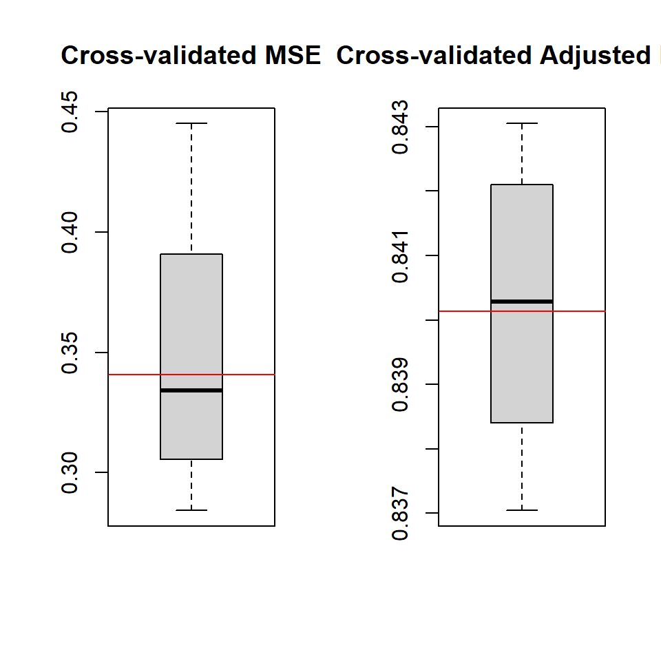

```r
k_fold_cv <- function(model, dataframe, k, seed){
  set.seed(seed)
  dataframe_shuffled <- dataframe[sample(nrow(dataframe)), ]
  folds <- split(seq(1, nrow(dataframe)), sort(rep_len(1:k, nrow(dataframe))))

  results <- matrix(, nrow = k, ncol= 4)
  colnames(results) <- c('mean res', 'sd res',  'MSE', 'Adj. R^2')

  results2 <- matrix(, nrow = k, ncol = length(names(model$coefficients)))
  colnames(results2) <- names(model$coefficients)

  results3 <- matrix(, nrow = k, ncol = length(names(model$coefficients)))
  colnames(results3) <- names(model$coefficients)

  for(i in seq(1, k)){
    test_fold <- dataframe_shuffled[unlist(folds[i]), ]
    train_fold <- dataframe_shuffled[-unlist(folds[i]), ]

    model_temp <- lm(model$call$formula, data = train_fold)
    test_fold$Preds <- predict(model_temp, test_fold)
    pred_err <- test_fold$Preds - sqrt(test_fold$Strength)

    results[i, ] <- c(mean(pred_err), sd(pred_err), mean(pred_err^2), summary(model_temp)$adj.r.squared)
    results2[i, ] <- summary(model_temp)$coefficients[, 1]
    results3[i, ] <- summary(model_temp)$coefficients[, 4]
  }
  return(list(metrics = results,
              params = results2,
              pvalues = results3))
}

cv <- k_fold_cv(challenger_model, df, 10, 123)
cv_params <- cv$params
cv_metrics <- cv$metrics
cv_pvals <- cv$pvalues

par(mfrow = c(1, 2))
boxplot(cv_metrics[, 'MSE'], main = "Cross-validated MSE")
abline(h= mean((challenger_model$fit - sqrt(df$Strength))^2), col='red')
boxplot(cv_metrics[, 'Adj. R^2'], main = "Cross-validated Adjusted R^2")
abline(h= summary(challenger_model)$adj.r.squared, col='red')
```

```r
cv_pvals %>% summary()
```

```
##   (Intercept)        poly(Cement, 2)1     poly(Cement, 2)2
##  Min.   :1.085e-13   Min.   : 0.000e+00   Min.   :3.218e-13
##  1st Qu.:1.092e-12   1st Qu.: 0.000e+00   1st Qu.:1.042e-12
##  Median :4.548e-12   Median : 0.000e+00   Median :5.819e-12
##  Mean   :2.896e-11   Mean   :5.104e-145   Mean   :2.153e-11
##  3rd Qu.:3.953e-11   3rd Qu.:1.321e-147   3rd Qu.:9.539e-12
##  Max.   :1.091e-10   Max.   :5.085e-144   Max.   :1.413e-10
##  I(CoarseAgg + FineAgg)      Ash            poly(Slag, 2)1
##  Min.   :4.200e-37      Min.   :1.500e-37   Min.   :0.000e+00
##  1st Qu.:1.300e-35      1st Qu.:7.849e-35   1st Qu.:1.700e-84
##  Median :2.759e-34      Median :2.253e-34   Median :1.036e-82
##  Mean   :1.198e-32      Mean   :2.678e-32   Mean   :1.197e-79
##  3rd Qu.:3.192e-33      3rd Qu.:1.966e-32   3rd Qu.:7.015e-80
##  Max.   :7.511e-32      Max.   :1.835e-31   Max.   :9.836e-79
##  poly(Slag, 2)2      sqrt(Superplasticizer) pmin(Age, 35)
##  Min.   :3.511e-06   Min.   :0.000413       Min.   : 0.000e+00
##  1st Qu.:4.871e-06   1st Qu.:0.001953       1st Qu.:6.000e-194
##  Median :1.043e-05   Median :0.002326       Median :1.517e-191
##  Mean   :3.859e-05   Mean   :0.005344       Mean   :1.211e-188
##  3rd Qu.:2.203e-05   3rd Qu.:0.003430       3rd Qu.:6.400e-191
##  Max.   :2.725e-04   Max.   :0.025087       Max.   :1.208e-187
```

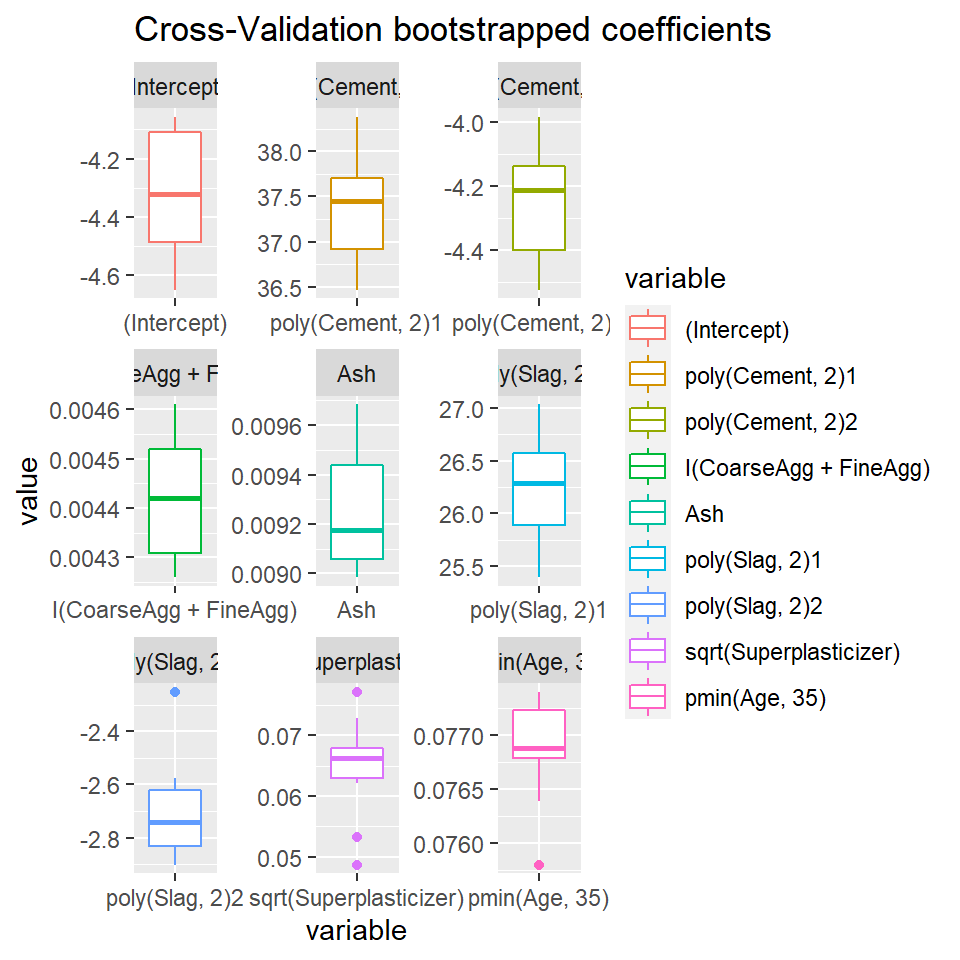

```r
cv_params %>% as_tibble() %>%
  as.data.table(keep.rownames = 'Vars') %>%
  melt(id.vars = "Vars") %>%
  mutate(Vars = as.numeric(Vars)) %>%
  ggplot(aes(x=variable, y = value, color = variable)) +
  geom_boxplot() + facet_wrap(~variable, scales='free', ncol = 3) +
  ggtitle("Cross-Validation bootstrapped coefficients")
```

Powyższe wykresy przedstawiają kolejno: boxplot *MSE* i *adjusted R<sup>2</sup>* bootstrapowanych przez $10$ foldów cross-validacji (czerwone linie to wartości dla pełnego modelu `challenger_model`), oraz rozkład wyestymowanych parametrów regresji, przy tych samych $10$ foldach cross-validacyjnych. Widzimy, że *MSE*, *adj. R<sup>2</sup>* oraz parametry modelu zachowują się stabilnie, tzn nie wykazują dużych wahań pomiędzy foldami cross-validacji. Wyżej widzimy też tabelę *summary* dla bootstrapowanych p-wartości parametrów regresji. Obserwując przedziały w jakie wpadały p-wartości widzimy że wybrane zmienne okazywały się istotne w każdym foldzie cross-validacyjnym. Powyższa analiza pozwala nam przypuszczać, że zależności prezentujące się w danych i wychwycone przez model nie były jedynie wynikiem losowego przypadku w danych treningowych.

Spójrzmy jeszcze czy nasz model dobrze generalizuje na nieznane dane. Wykonujemy predykcje na wyodrębnionym z analizy zbiorze testowym i nanosimy *MSE* predykcji niebieskim kolorem na wcześniej widziany boxplot z cross-validacji. Wykonujemy również porównanie wykresów kernel smoothed density dla błędów predykcji na zbiorach testowym i treningowym.

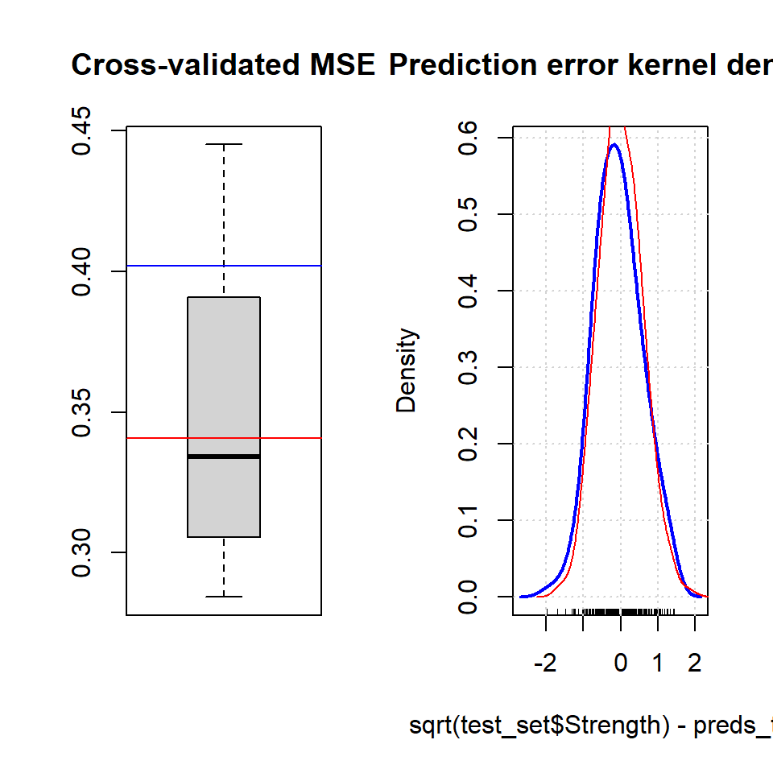

```r
par(mfrow=c(1, 2))
preds_test <- predict(challenger_model, test_set)

boxplot(cv_metrics[, 'MSE'], main = "Cross-validated MSE")
abline(h= mean((challenger_model$fit - sqrt(df$Strength))^2), col='red')
abline(h= mean((preds_test - sqrt(test_set$Strength))^2), col='blue')

densityPlot(sqrt(test_set$Strength) - preds_test, method='kernel', col='blue', main = "Prediction error kernel density")
lines(kde$x, kde$y, col='red')
```

Widzimy, że *MSE* na zbiorze testowym wpada wewnątrz wąsów boxplotu obliczonych na podstawie cross-validowanego rozkładu *MSE*. Również gęstość rozkładu reziduów modelu na danych treningowych i testowych są blisko siebie. Konluzją jest więc, że nic nie wskazuje na to aby model był przeuczony do zbioru treningowego.

# 6 Podsumowanie

Jest to model o stosunkowo dużym stopniu skomplikowania, lecz stabilność modelu i zdolność generalizowania na nieznane dane nie zostałą poddana pod wątpliwość podczas cross-validacji.

Ceteris paribus, widzimy że pierwiastek wytrzymałości ściskowej betonu najbardziej reaguje na wzrost ilości cementu oraz żużlu w mieszance. Są to jednak transformacje funkcją kwadratową, o ujemnym współczynniku w drugiej potędze - to znaczy, że gdy ilość cementu lub żużlu przekroczy pewne maksimum, zaczyna negatywnie wpływać na wytrzymałość produktu. Pierwiastek ilości superplastyfikatora, ilość pyłu, oraz ilość kruszywa (grubo, czy drobno ziarnistego) wpływają pozytywnie, liniowo na pierwiastek wytrzymałości ściskowej betonu; w mniejszym stopniu od pozostałych zmiennych.

Widzimy też, że model dobrze akomoduje rzeczywistość pod względem zależności wytrzymałości betonu od czasu wiązania. Liniowa zależność dla pierwszego miesiąca, oraz jej wygaszenie później zdaje się dobrze wyjaśniać zmienność w modelu.

Otzymany model ma *adjusted R<sup>2</sup>* $=0.8401$ (nastąpiła poprawa od $0.61$ dla pierwszego naiwnego modelu), więc dość dobrze wyjaśnia zmienność w danych. Błąd modelu można skwantyfikować przez *MSE*$=52.1406$, co jest dwukrotnie mniejszym *MSE* niż w modelu naiwnym.

Rezidua modelu przechodzą test Shapiro-Wilka na normalność, oraz test non-constant Variance Score na homoskedastyczność. Nie wydają się zależne od zmiennych, ani interakcji między nimi.

Analiza obserwacji odstających, nie wykazała żadych obserwacji które byłby jednocześnie wpływowe dla modelu, oraz w znaczący sposób nietypowe.

## 6.1 Wnioski

Transformacje zmiennych niezależnych pozwalają na dopasowanie dość dobrego modelu regresji wielorakiej dla wytrzymałości betonu. Otrzymaliśmy istotny statystycznie model, o dobrych zdolnościach predykcyjnych, którego rezidua spełniają założenia regresji liniowej. Czytając literaturę o wytrzymałości materiałów, mogę podejrzewać, że dałoby się poprawić model uwzględniając dodatkowo temperaturę w której wiązał się beton. Nie mieliśmy jednak dostępu do tej danej, więc finalny rezultat jest satysfakcjonujący.